# Maternal Health Risk Prediction and Prevention Methods

**Author:** Bryan Rickens

**Email:** rickensbj@g.cofc.edu

```python
import pandas as pd
```

# Part 1 - Introduction

Improving maternal health remains one of the [biggest goals for the United Nations](https://www.un.org/millenniumgoals/pdf/Goal_5_fs.pdf). While much progress has been made in the last few decades, the UN still seeks to further improve maternal mortality and overall well-being for expectant mothers across the globe. With the advent of advanced machine learning and statistical techniques, this goal is actively being pursued by researching communities worldwide. [Our dataset](https://archive.ics.uci.edu/ml/datasets/Maternal+Health+Risk+Data+Set), gathered from the UCI Machine Learning Repository, is from one such study.

Utilizing new technologies based on the Internet of Things (IoT), [this study](https://ieeexplore.ieee.org/document/9350320) uses data collected from different hospitals, community clinics, and maternal health cares from the rural areas of Bangladesh, India. Many mothers in developing (and even developed) countries may not have immediate access to maternal health care, and may not be aware or able to address medical concerns during their pregnancy. [With remote-based monitoring technologies with risk-level prediction](https://doi.org/10.1007/978-981-15-2317-5_30), women will be immediately alerted when potential dangers are measured and can proactively seek medical help regarding the issue at hand. Our research seeks to utilize such a dataset to predict maternal risk-levels during pregnancy, and to find relationships between features to further identify the most pressing health risks that women face during this period.

# Part 2 - Methodology

Below is a breakdown of all the features utilied in our dataset:

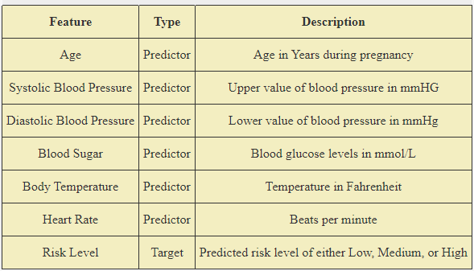

```python
# Example of Heart Rate Error:

df = pd.read_csv("Maternal Health Risk Data Set.csv")

df['HeartRate'].sort_values().head(5)
```

```
908     7
499     7
702    60
783    60
784    60
Name: HeartRate, dtype: int64
```

## Feature Analysis

We can see a near-even breakdown of Risk Level. With a balanced distribution of classes, we can be confident that each one is fairly represented in the data.

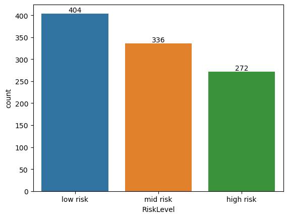

<sub>Figure 1: Distribution of Risk Level</sub>

Below details histograms for each feature.

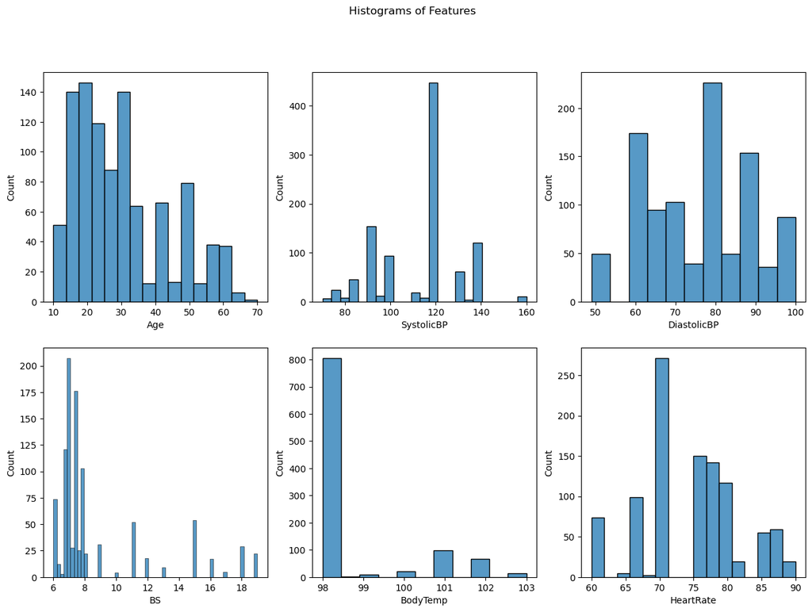

<sub>Figure 2: Histogram per Feature</sub>

The next figure details boxplots for each feature and their respective Risk Levels:

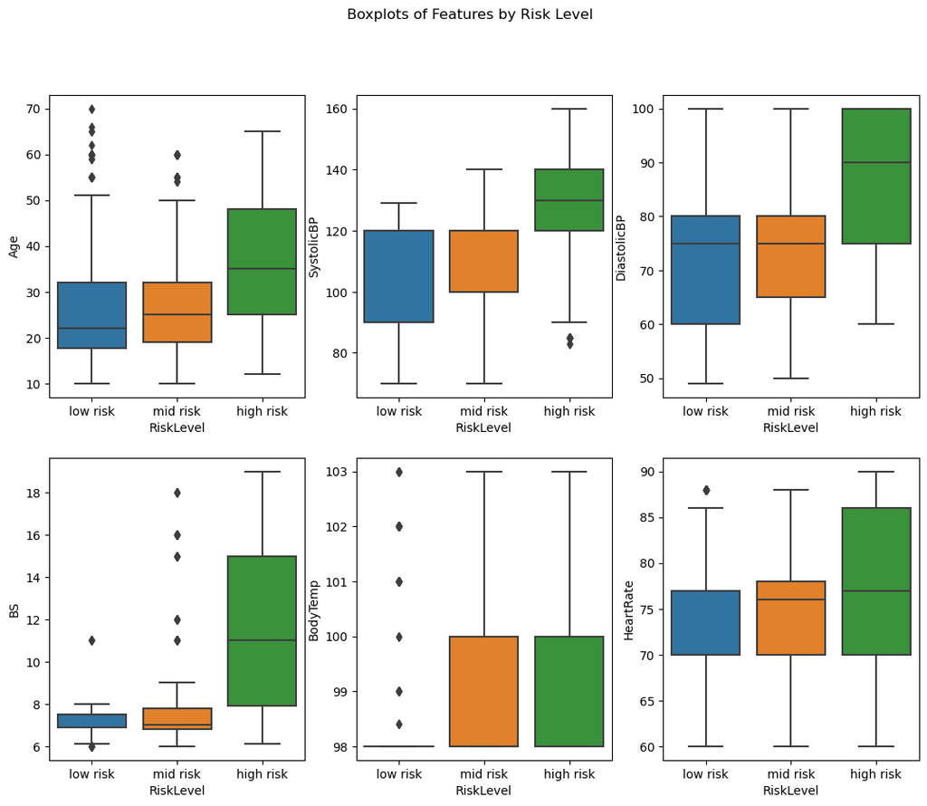

<sub>Figure 3: Boxplot per Feature</sub>

Valuable information can be gleaned from each, wherein the majority of figures exhibit a near linear relationship between the feature and the associated Risk Level. For example, the medians and innermost quartiles for Ages increase for each respective Risk Level (with the median age for Low Risk being in the low 20s and the median age for High Risk being in the mid 30s). Similarly, Blood Sugar levels have a much lower median and range for those of Low Risk while those of High Risk exhibit levels with a much higher median and range. It should be noted, however, that outliers are present for many features and that the ranges are not exclusively linear between Risk Levels.

## Model Construction

The first model chosen for our analysis was a Random Forest model. Due to the insights gleaned from our exploratory analysis (specifically concerning the near-linear trend of Risk Levels per feature), we chose a Random Forest model as our first model for a select few reasons. Primarily, due to the significant presence of outliers despite the near-linear relationship per Risk Level, we doubted the performance of models with a foundational structure of linear separability. Secondarily, due to the algorithmic nature of decision trees, we knew that interaction between features would be automatically considered by the model without having to explicitly discover and label them as required by a linear one. In lieu of bagging, we also chose Random Forests to ensure that feature importance would have a wide range of potential (whereas in the case of bagging, the potential for one feature to be dominant in all constructed trees would be high).

This model was constructed in Python using the scikit-learn library. The cross validation method used was a Random Stratified K-Fold selection. A stratified fold was selected to ensure class balance was maintained in each split. We chose a k-fold of 5, and repeated it 3 times to ensure a wide selection of data was used in the construction of the model.

```python
# Manually encode our Target classes
# (for models with a high degree of classes, use sklearn's Label Encoder)
df['RiskLevel'].replace(to_replace = {
    'high risk': int(3),
    'mid risk': int(2),
    'low risk': int(1)
}, inplace = True)
```

For a more robust analysis, instead of using built-in methods such as sklearn's cross_val_score (which output's the cross validated model's mean score for each but lacks the ability for deeper inspection), a custom function is built to ultimately combine each cross validated model and output a combined confusion matrix, classification report, and even a combined results data frame to allow post-result analysis.

```python
# Required libraries
import copy as cp
from typing import Tuple
import numpy as np
from sklearn.model_selection import RepeatedStratifiedKFold
from sklearn.ensemble import RandomForestClassifier

def cross_val_predict(model, cv : RepeatedStratifiedKFold, X : np.array, y : np.array) -> Tuple[np.array, np.array, np.array]:
    """ This function takes a model and a cross validation method and returns a combined array of
        all the actual classes, the predicted classes, and predicted probabilities.

input:
    model type,
    cross validation method,
    X values,
    y values
output:
    combined actual classes,
    combined predicted classes,
    combined predicted probabilities """

    # Take a local copy of the model
    model_ = cp.deepcopy(model)

    # Take number of target classes
    no_classes = len(np.unique(y))

    # Construct new arrays to later insert the outputs into
    actual_classes = np.empty([0], dtype=int)
    predicted_classes = np.empty([0], dtype=int)
    index = np.empty([0], dtype=int)
    predicted_proba = np.empty([0, no_classes])


    # Iterate by train/test index throgh the selected CV method
    for train_index, test_index in cv.split(X,y):

        # Train/test split on current fold
        train_X, train_y, test_X, test_y = X[train_index], y[train_index], X[test_index], y[test_index]

        # Append the actual (test) classes
        actual_classes = np.append(actual_classes, test_y)

        # Fit the model on current fold
        model_.fit(train_X, train_y)

        # Append the class predictions the model made on current fold
        predicted_classes = np.append(predicted_classes, model_.predict(test_X))

        #Append the original index location
        index = np.append(index, test_index)
        # Append predicted probability
        try:
            predicted_proba = np.append(predicted_proba, model_.predict_proba(test_X), axis=0)

        # Append 0 upon error
        except:
            predicted_proba = np.append(predicted_proba, np.zeros((len(test_X), no_classes), dtype=float), axis=0)

    # Return combined array of all actual, predicted, and probabilities across all folds
    return actual_classes, predicted_classes, predicted_proba, index

#* function adapted from TowardsDataScience
```

```python
# Required Libraries
from sklearn.metrics import confusion_matrix
import matplotlib.pyplot as plt
import seaborn as sns
from sklearn.metrics import classification_report

def plot_results(actual_classes : np.array, predicted_classes : np.array, sorted_labels : list):
    """ This function constructs a confusion matrix based on the combined results of each cross validation

input:
    combined actual classes array,
    combined predicted classes array,
    list of sorted class labels

output:
     combined confusion matrix,
     printed classification report"""

    # Construct CM using sklearn's imported method
    matrix = confusion_matrix(actual_classes, predicted_classes)

    # Use SNS for better visualizaiton and plot
    plt.figure(figsize=(7,5))
    sns.heatmap(matrix, annot=True, xticklabels=sorted_labels, yticklabels=sorted_labels, cmap="Blues", fmt="g")
    plt.xlabel('Predicted'); plt.ylabel('Actual'); plt.title('Confusion Matrix for Random Forest (Repeated Statified KFolds)')
    plt.show()

    # Also print results using sklearn's imported method
    print(classification_report(actual_classes, predicted_classes))
```

# Part 3 - Model Results

First, let's view the difference between the simple built-in method of sklearn's cross_validation_score versus the custom one we built:

```python
# Simple built-in sklearn method

from sklearn.model_selection import cross_val_score
from sklearn.model_selection import RepeatedStratifiedKFold

# Define predictors and target
X = df.iloc[:, :-1]
y = df.iloc[:, -1]

# Construct RF model
model = RandomForestClassifier()

# Construct CV
cv = RepeatedStratifiedKFold(n_splits = 5, n_repeats = 3, random_state = 0)
cvscore = cross_val_score(model,X,y,cv = cv)
print(cvscore.mean())
```

```
0.8425238582971597
```

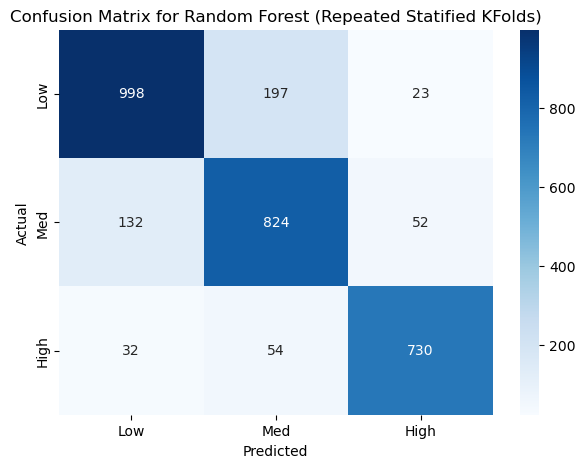

```
              precision    recall  f1-score   support

           1       0.86      0.82      0.84      1218
           2       0.77      0.82      0.79      1008
           3       0.91      0.89      0.90       816

    accuracy                           0.84      3042
   macro avg       0.84      0.84      0.84      3042
weighted avg       0.84      0.84      0.84      3042
```

```python
# Robust custom function

actual_classes, predicted_classes, predicted_proba, index = cross_val_predict(model, cv, X.to_numpy(), y.to_numpy())
plot_results(actual_classes, predicted_classes, ['Low','Med','High'])
```

<sub>Figure 4: Confusion Matrix and Classification Report</sub>

As you can see, instead of simply only returning the score of the cross validation method, we can now analyze the same results more in-depth using the custom function.

Two methods were used to obtain feature importance for our Random Forest model: scikit-learn’s built-in method based on Gini Importance and SHAP, a custom Python library built using [Shapley values based on game theory](https://doi.org/10.1038/s42256-019-0138-9).

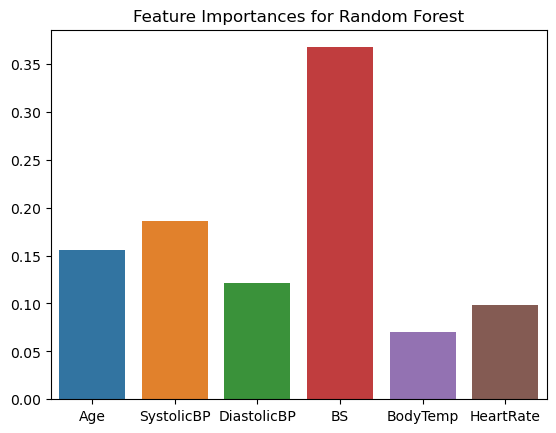

<sub>Figure 5: Gini Importance for Random Forest</sub>

For the Gini importance as seen above, it appears that our model overwhelmingly valued Blood Sugar levels in its classifications. This is not entirely unexpected after recalling an earlier Figure 3 (boxplots per feature) which highlighted Blood Sugar having the highest range of variation between Risk Levels. Similarly, remembering the high skew of Body Temperature back in Figure 2 (histograms per feature), it is also not unsurprising that this feature was valued the least.

The alternative Shapley values for each feature can be seen below in Figure 6.

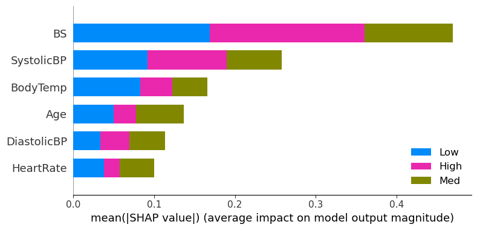

<sub>Figure 6: Shapley Feature Importance for Random Forest Model</sub>

An added benefit of the Shapley interpretation is being able to visualize the mean importance of features per classification – and how features differ in importance between each. Figures 7, 8, and 9 show the feature importance for Low, Medium, and High Risk classifications made by our model respectively. A lot more information can be gleaned from these specific plots as compared to the standard Gini Importance.

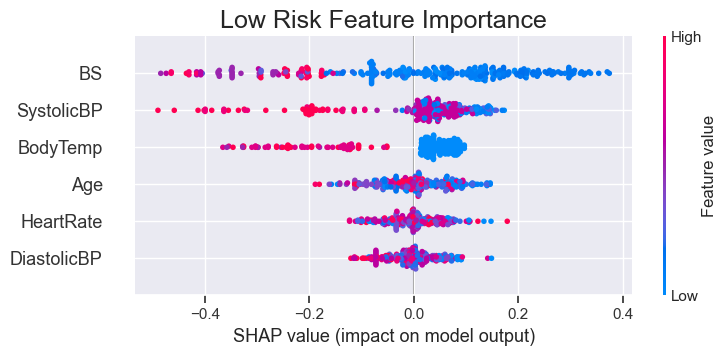

<sub>Figure 7: Feature Importance for Low Risk Classifications</sub>

For example, referring to Figure 7 above for Low Risk Classifications made, we can see that medium to high values of Blood Sugar decreased the model’s influence of assigning as Low Risk, while low values showed a very high increase in the influence of labeling it as Low. Similarly, high to medium values of Body Temperature have negative influence while low values show a positive influence in classifying a patient as Low Risk. It also helps visualize more convoluted influences – in the same figure for Systolic Blood Pressure, we can see that extremely high values decrease the influence by a wide margin, but medium to low values exhibit a combined similar influence that only marginally show an increased feature importance. This is suggestive that unless Systolic Blood Pressure has an extremely high value, the model struggles to delineate the importance between medium to low values. Recalling the classification report above in Figure 4 and how the model had similar accuracies between Low and Medium risk classifications, this seems to further illustrate how the Random Forest most easily classifies High Risk in comparison to the others.

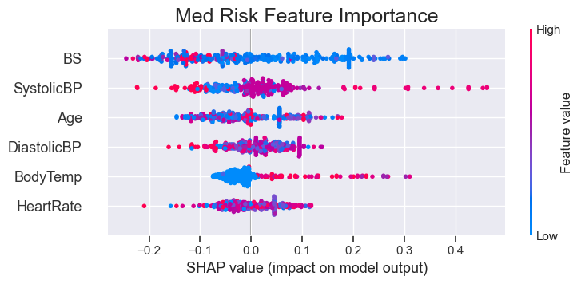

<sub>Figure 8: Feature Importance for Medium Risk Classifications</sub>

Analyzing Figure 8 for Medium Risk classifications further demonstrates the model's struggle in identifying feature importance for this class output. For example, starting with Blood Sugar, we see that while most low values led to to a higher probability of classifying it as Medium, it still included quite a few low values amongst the other higher measurements on the opposite end (indicating a lower probability of classifying it as Medium). Similarly for Systolic BP, we see that while high values have a large decrease in Medium classification and low values have a marginal decrease, the middle ranged values for Systolic BP led to an increased Medium classification probability.

Features like Age, Diastolic BP, and Heart Rate are shown to be almost ineffective in Medium classifications, as values for each feature span the entirety of the distribution with seemingly no pattern, all leading to different probabilites of classification.

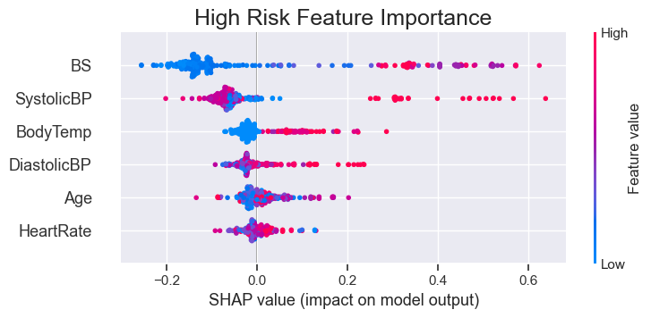

<sub>Figure 9: Feature Importance for High Risk Classifications</sub>

In comparison in Figure 9, we can see which features and their values influence High Risk classifications: high values for Blood Sugar, both Blood Pressures, and Body Temperatures all have a high influence in classifying a patient as High Risk. Overall for each level of classification, we can see that the features of Age and Heart Rate have little to no influence on classification. In future models, these could potentially be removed.

## Type 2 Error / Misclassification Assessment

To finalize our Random Forest results, we look at what we would define as Type II errors – actual High Risk Levels that were incorrectly classified as Low Risk in our model. In a real life scenario of model deployment, this would be the worst case possibility and it is important to understand the faults of this Random Forest model.

```python
# Create results data frame from the output of our custom function
results = pd.DataFrame({
    'Actual': actual_classes,
    'Predicted': predicted_classes,
    'Index' : index })

# Match the index from the original data frame
results.set_index('Index',inplace = True)

# Drop duplicate indicies
results = results[~results.index.duplicated(keep='first')]

# Add in the original feature information for analysis
results['Age'] = df['Age']
results['SystolicBP'] = df['SystolicBP']
results['DiastolicBP'] = df['DiastolicBP']
results['BS'] = df['BS']
results['BodyTemp'] = df['BodyTemp']
results['HeartRate'] = df['HeartRate']
```

```python
# Filter and locate the Type 2 Errors
type_2 = results.loc[(results['Actual'] == 3) & (results['Predicted'] == 1)]
type_2
```

| Index | Actual | Predicted | Age | SystolicBP | DiastolicBP | BS | BodyTemp | HeartRate |
| --- | --- | --- | --- | --- | --- | --- | --- | --- |
| 353 | 3 | 1 | 40 | 120 | 90 | 6.9 | 98.0 | 80 |
| 390 | 3 | 1 | 17 | 85 | 69 | 7.8 | 102.0 | 86 |
| 354 | 3 | 1 | 55 | 110 | 85 | 6.9 | 98.0 | 88 |
| 620 | 3 | 1 | 17 | 85 | 60 | 7.5 | 101.0 | 86 |
| 355 | 3 | 1 | 25 | 100 | 90 | 6.9 | 98.0 | 76 |
| 610 | 3 | 1 | 13 | 90 | 65 | 7.5 | 101.0 | 80 |
| 238 | 3 | 1 | 17 | 90 | 63 | 8.0 | 101.0 | 70 |
| 301 | 3 | 1 | 40 | 120 | 75 | 7.7 | 98.0 | 70 |
| 987 | 3 | 1 | 17 | 90 | 63 | 8.0 | 101.0 | 70 |
| 1007 | 3 | 1 | 40 | 120 | 75 | 7.7 | 98.0 | 70 |
| 191 | 3 | 1 | 17 | 90 | 65 | 6.1 | 103.0 | 67 |
| 356 | 3 | 1 | 35 | 120 | 80 | 6.9 | 98.0 | 80 |
| 970 | 3 | 1 | 17 | 90 | 65 | 6.1 | 103.0 | 67 |

Above we can see that since perhaps Blood Sugar and Systolic Blood Pressure were not as high as other High Risk classifications (recalling Figure 9 where high values led to higher probabilities of High classification), it mistakenly labeled them as Low Risk. While these Type II error classifications only account for a miniscule percentage of the test results, it is still something to consider and to look out for.

# Part 4 - Conclusion

As far as feature analysis is concerned, our biggest takeaway is the influence of Blood Sugar and Systolic Blood Pressure on the data set. While not completely without main effects, the other features were not as influential. Once again recalling the limitations of the dataset and its sampling of rural areas of Bangladesh, perhaps other models could have performed differently in different populations and seen different feature importance.

In conclusion, I hope to have demonstrated the efficacy of machine learning in the application of maternal health risk analysis. As the Internet of Things becomes more commonplace throughout the world, those of developing nations can utilize models like these to strive further towards the United Nations’ goal of reducing maternal mortality. This model has highlighted the importance of glucose and blood pressure levels during pregnancy – so even without remote-sensing, expecting mothers can use these findings on what to be concerned of and what to keep an eye on. Overall, we hope to have contributed to this problem and are interested in seeing where further research leads.